# Brain Stroke Prediction - Code & Technical Analysis

Team Sage

2022-11-02

```r
knitr::opts_chunk$set(echo = TRUE)
```

```r
library(ggplot2)
library(gridExtra)
library(corrplot)
library(ROSE)
library(dplyr)
stroke_df = read.csv("healthcare-dataset-stroke-data.csv")
```

```r
str(stroke_df)
```

```
## 'data.frame':    5110 obs. of  12 variables:
##  $ id               : int  9046 51676 31112 60182 1665 56669 53882 10434 27419 60491 ...
##  $ gender           : chr  "Male" "Female" "Male" "Female" ...
##  $ age              : num  67 61 80 49 79 81 74 69 59 78 ...
##  $ hypertension     : int  0 0 0 0 1 0 1 0 0 0 ...
##  $ heart_disease    : int  1 0 1 0 0 0 1 0 0 0 ...
##  $ ever_married     : chr  "Yes" "Yes" "Yes" "Yes" ...
##  $ work_type        : chr  "Private" "Self-employed" "Private" "Private" ...
##  $ Residence_type   : chr  "Urban" "Rural" "Rural" "Urban" ...
##  $ avg_glucose_level: num  229 202 106 171 174 ...
##  $ bmi              : chr  "36.6" "N/A" "32.5" "34.4" ...
##  $ smoking_status   : chr  "formerly smoked" "never smoked" "never smoked" "smokes" ...
##  $ stroke           : int  1 1 1 1 1 1 1 1 1 1 ...
```

```r
head(stroke_df)
```

```
##      id gender age hypertension heart_disease ever_married     work_type
## 1  9046   Male  67            0             1          Yes       Private
## 2 51676 Female  61            0             0          Yes Self-employed
## 3 31112   Male  80            0             1          Yes       Private
## 4 60182 Female  49            0             0          Yes       Private
## 5  1665 Female  79            1             0          Yes Self-employed
## 6 56669   Male  81            0             0          Yes       Private
##   Residence_type avg_glucose_level  bmi  smoking_status stroke
## 1          Urban            228.69 36.6 formerly smoked      1
## 2          Rural            202.21  N/A    never smoked      1
## 3          Rural            105.92 32.5    never smoked      1
## 4          Urban            171.23 34.4          smokes      1
## 5          Rural            174.12   24    never smoked      1
## 6          Urban            186.21   29 formerly smoked      1
```

```r
stroke_df = subset(stroke_df, select = -c(id))

# converting the numeric variables to factor variables
stroke_df$gender = as.factor(stroke_df$gender)
stroke_df$hypertension = as.factor(stroke_df$hypertension)
stroke_df$heart_disease = as.factor(stroke_df$heart_disease)
stroke_df$ever_married = as.factor(stroke_df$ever_married)
stroke_df$bmi = as.numeric(stroke_df$bmi)
stroke_df$stroke = as.factor(stroke_df$stroke)

# To get the summary statistics of the dataset
summary(stroke_df)
```

```
##     gender          age        hypertension heart_disease ever_married
##  Female:2994   Min.   : 0.08   0:4612       0:4834        No :1757
##  Male  :2115   1st Qu.:25.00   1: 498       1: 276        Yes:3353
##  Other :   1   Median :45.00
##                Mean   :43.23
##                3rd Qu.:61.00
##                Max.   :82.00
##
##   work_type         Residence_type     avg_glucose_level      bmi
##  Length:5110        Length:5110        Min.   : 55.12    Min.   :10.30
##  Class :character   Class :character   1st Qu.: 77.25    1st Qu.:23.50
##  Mode  :character   Mode  :character   Median : 91.89    Median :28.10
##                                        Mean   :106.15    Mean   :28.89
##                                        3rd Qu.:114.09    3rd Qu.:33.10
##                                        Max.   :271.74    Max.   :97.60
##                                                          NA's   :201
##  smoking_status     stroke
##  Length:5110        0:4861
##  Class :character   1: 249
##  Mode  :character
##
##
##
##
```

```r
# To find the NA's in the dataset
paste("The NA's in the dataset is:",sum(is.na(stroke_df)))
```

```
## [1] "The NA's in the dataset is: 201"
```

```r
# Replacing NA values with average BMI value
stroke_df$bmi[is.na(stroke_df$bmi)] = mean(stroke_df$bmi,na.rm = TRUE)
paste("The NA's in the dataset after imputation of BMI with mean is:",sum(is.na(stroke_df)))
```

```
## [1] "The NA's in the dataset after imputation of BMI with mean is: 0"
```

```r
# since we had only 1 data point in others category for gender we are removing it
stroke_df = subset(stroke_df,gender!="Other")
summary(stroke_df)
```

```
##     gender          age        hypertension heart_disease ever_married
##  Female:2994   Min.   : 0.08   0:4611       0:4833        No :1756
##  Male  :2115   1st Qu.:25.00   1: 498       1: 276        Yes:3353
##  Other :   0   Median :45.00
##                Mean   :43.23
##                3rd Qu.:61.00
##                Max.   :82.00
##   work_type         Residence_type     avg_glucose_level      bmi
##  Length:5109        Length:5109        Min.   : 55.12    Min.   :10.30
##  Class :character   Class :character   1st Qu.: 77.24    1st Qu.:23.80
##  Mode  :character   Mode  :character   Median : 91.88    Median :28.40
##                                        Mean   :106.14    Mean   :28.89
##                                        3rd Qu.:114.09    3rd Qu.:32.80
##                                        Max.   :271.74    Max.   :97.60
##  smoking_status     stroke
##  Length:5109        0:4860
##  Class :character   1: 249
##  Mode  :character
##
##
##
```

```r
# subsetting the data for various analyses
stroke_1 = subset(stroke_df, stroke == 1)
stroke_0 = subset(stroke_df, stroke == 0)
stroke_1_female = subset(stroke_df, stroke == 1 & gender == "Female")
stroke_1_male = subset(stroke_df, stroke == 1 & gender == "Male")

# creating different columns for bmi, age and average_glucose_level based on different bucketing for each variables
dat <- within(stroke_df, {
  bmi.cat = NA # need to initialize variable
  bmi.cat[bmi < 18.5] = "underweight"
  bmi.cat[bmi >= 18.5 & bmi < 25] = "normal"
  bmi.cat[bmi >= 25 & bmi < 30] = "overweight"
  bmi.cat[bmi >= 30 & bmi < 40] = "obesity"
  bmi.cat[bmi >=40] = "severe obesity"
  avg_gluc.cat = NA # need to initialize variable
  avg_gluc.cat[avg_glucose_level < 60] = "Below 60"
  avg_gluc.cat[avg_glucose_level >= 60 & avg_glucose_level < 90] = "60 - 90"
  avg_gluc.cat[avg_glucose_level >= 90 & avg_glucose_level < 120] = "90 - 120"
  avg_gluc.cat[avg_glucose_level >= 120 & avg_glucose_level < 180] = "120 - 180"
  avg_gluc.cat[avg_glucose_level >= 180 & avg_glucose_level < 273] = "180 - 273"
  age.cat = NA
  age.cat[age<=20] = "Under 20"
  age.cat[age>=21 & age<= 40 ] = "20-40"
  age.cat[age>=41 & age<= 60 ] = "40-60"
  age.cat[age>=61 & age<= 80 ] = "60-80"
  age.cat[age>=80 ] = "above 80"
   } )

dat$bmi.cat<- factor(dat$bmi.cat,levels= c("underweight","normal","overweight","obesity","severe obesity" ))
dat$avg_gluc.cat<- factor(dat$avg_gluc.cat,levels= c("Below 60","60 - 90","90 - 120","120 - 180","180 - 273" ))
dat$age.cat<- factor(dat$age.cat,levels= c("Under 20","20-40","40-60","60-80","above 80"))
```

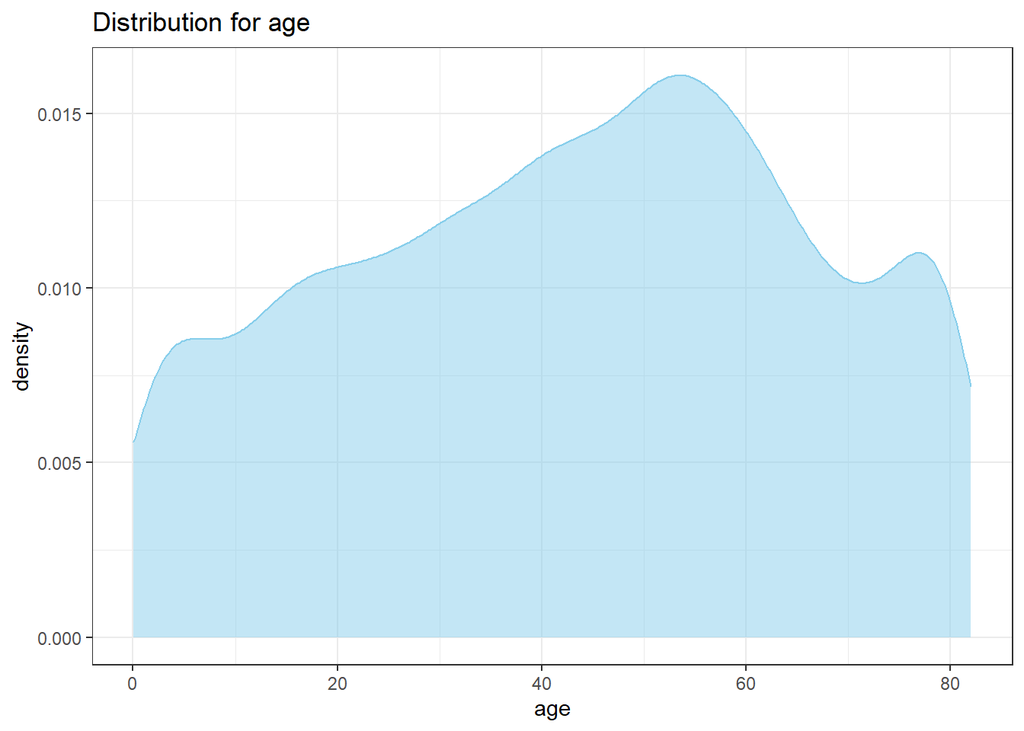

```r
ggplot(stroke_df, aes(x=age)) +  geom_density(fill="skyblue", color="skyblue", alpha=0.5)+ theme_bw() + theme()+ ggtitle("Distribution for age")
```

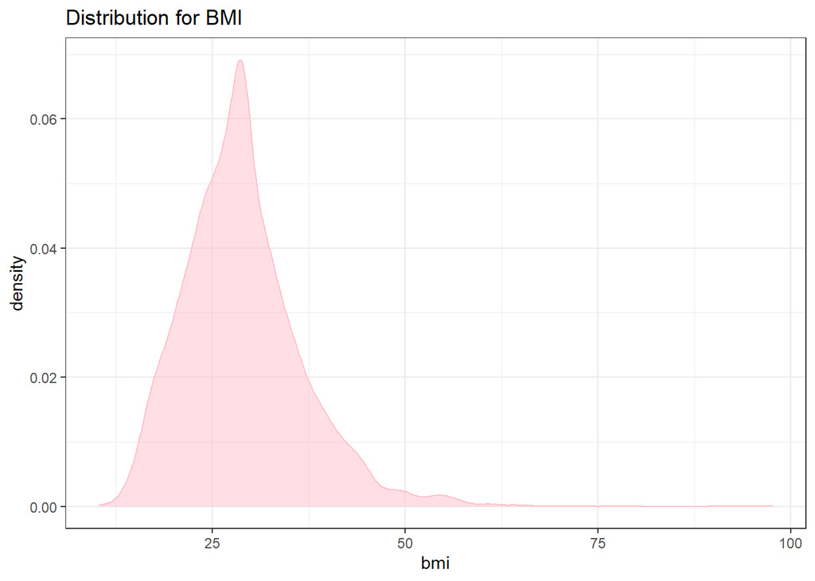

```r
ggplot(stroke_df, aes(x=bmi)) +  geom_density(fill="pink", color="pink", alpha=0.5)+ theme_bw() + theme()+ ggtitle("Distribution for BMI")
```

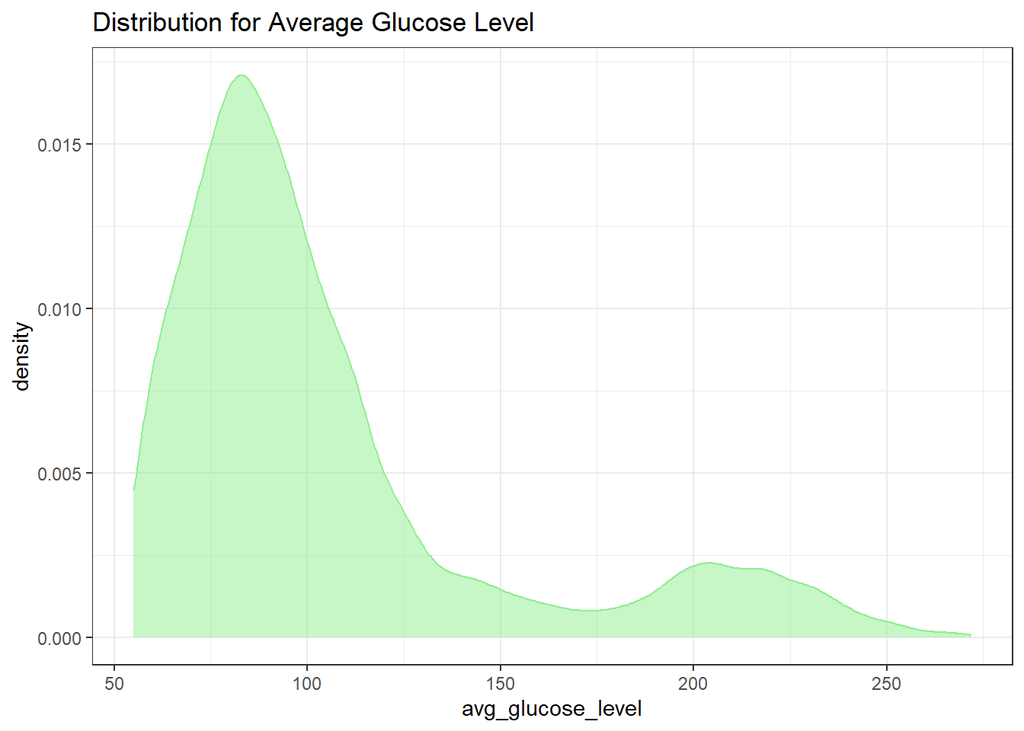

```r
ggplot(stroke_df, aes(x=avg_glucose_level)) +  geom_density(fill="lightgreen", color="lightgreen", alpha=0.5)+ theme_bw() + theme()+ ggtitle("Distribution for Average Glucose Level")
```

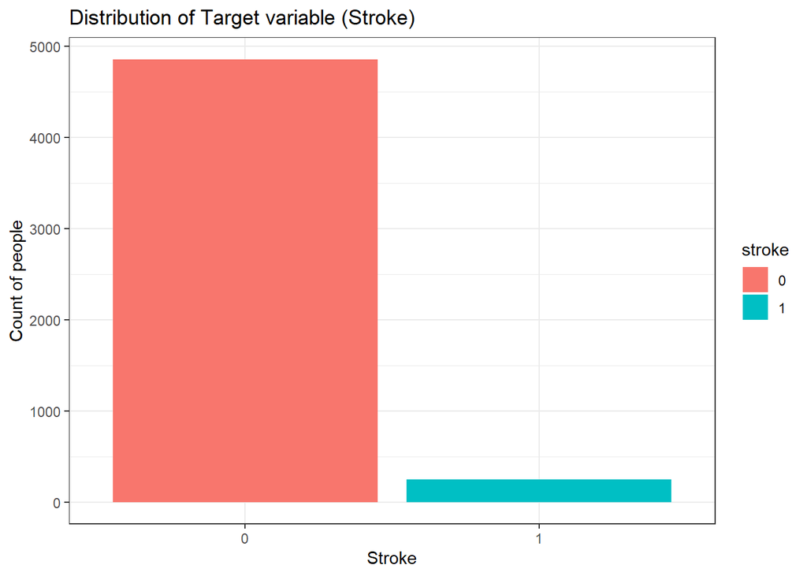

```r
ggplot(stroke_df, aes(x=stroke,fill=stroke))+geom_bar()+ggtitle("Distribution of Target variable (Stroke)")+ theme_bw() + theme()+ xlab("Stroke") + ylab("Count of people")
```

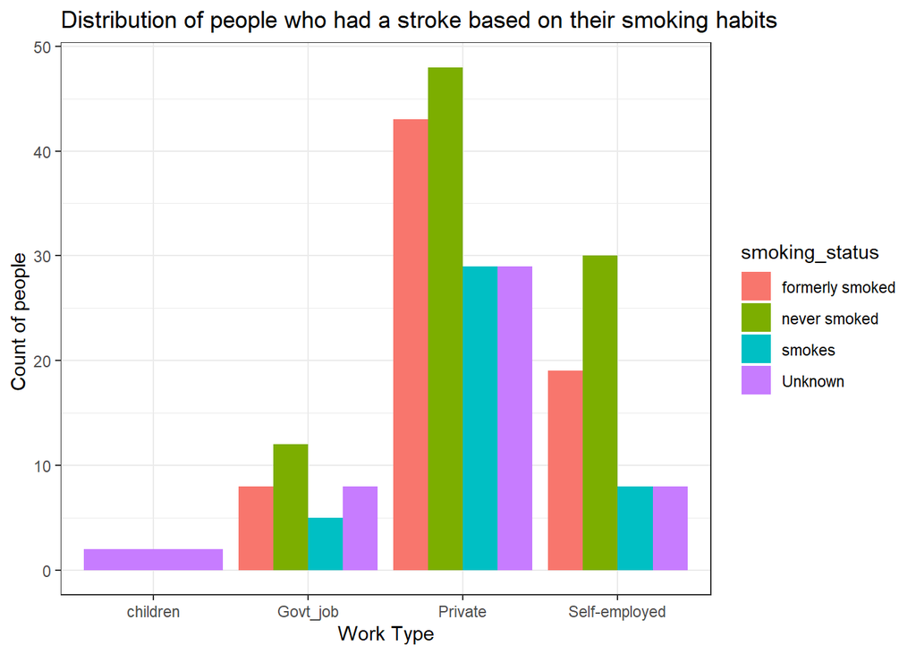

```r
ggplot(stroke_1,aes(x=work_type, fill= smoking_status))+geom_bar(position = "dodge")+ggtitle("Distribution of people who had a stroke based on their smoking habits")+ theme_bw() + theme()+ xlab("Work Type") + ylab("Count of people ")
```

The above graph only includes those who have had a stroke, and we can see from the graph that most people in the private sector and self-employed have had a stroke, and it’s worth noting that the two major causes of stroke were those who had never smoked and those who had formerly smoked.

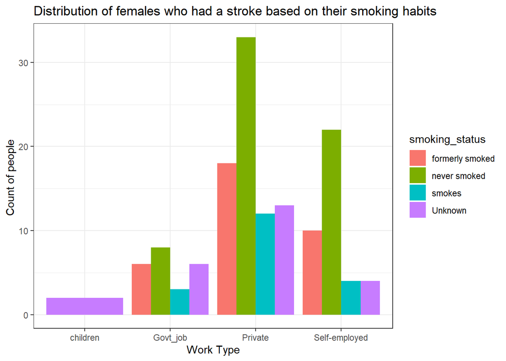

```r
ggplot(stroke_1_female,aes(x=work_type, fill= smoking_status))+geom_bar(position = "dodge")+ggtitle("Distribution of females who had a stroke based on their smoking habits")+ theme_bw() + theme()+ xlab("Work Type") + ylab("Count of people ")
```

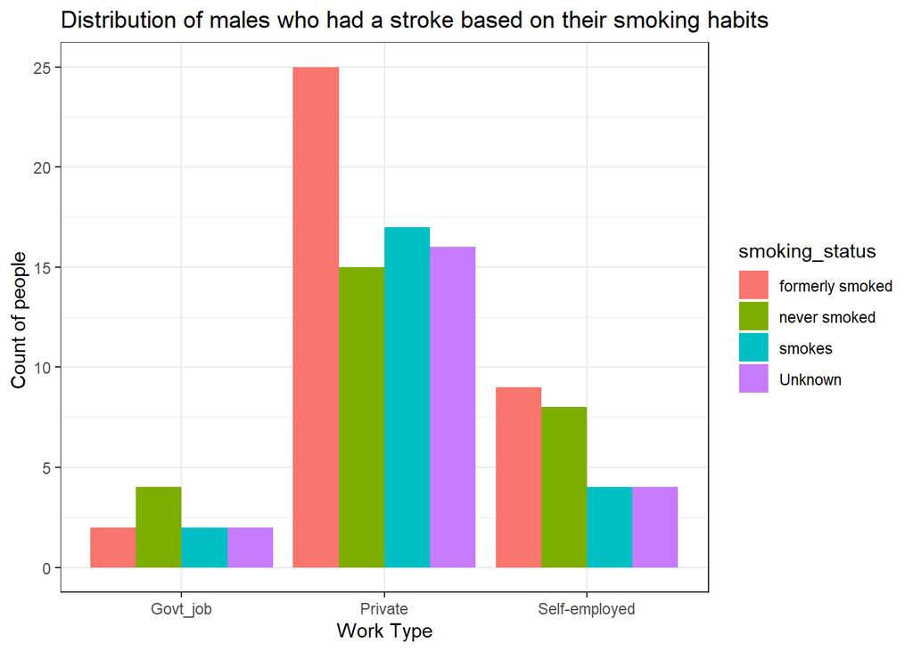

```r
ggplot(stroke_1_male,aes(x=work_type, fill= smoking_status))+geom_bar(position = "dodge")+ggtitle("Distribution of males who had a stroke based on their smoking habits")+ theme_bw() + theme()+ xlab("Work Type") + ylab("Count of people ")
```

As seen in the graph above, the key causes that caused a stroke in females were never smoked and formerly smoked, whereas in males, the reason for stroke was formerly smoked and smokes in the private sector, and formerly smoked and never smoked in the self-employed sector.

To see if these variables are dependent we did a chi square test.

```r
ctest1 = chisq.test(dat$smoking_status, dat$stroke)
ctest2 = chisq.test(dat$work_type, dat$stroke)
ctest1
```

```
##
##  Pearson's Chi-squared test
##
## data:  dat$smoking_status and dat$stroke
## X-squared = 29.226, df = 3, p-value = 2.008e-06
```

```r
ctest2
```

```
##
##  Pearson's Chi-squared test
##
## data:  dat$work_type and dat$stroke
## X-squared = 49.159, df = 4, p-value = 5.409e-10
```

As we can see from the results, the p values for both tests are less than 0.05, thus we can fail to accept the null hypothesis and infer that smoking status and work type are related to stroke.

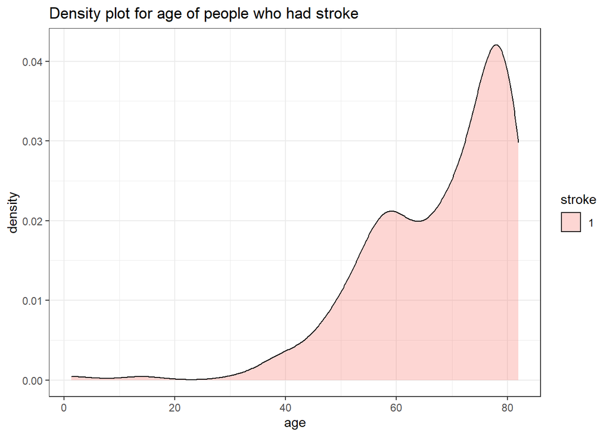

```r
ggplot(stroke_1, aes(x = age, fill=stroke))+ geom_density(alpha = 0.3)+ ggtitle("Density plot for age of people who had stroke")+ theme_bw() + theme()
```

In general, we know that as one gets older, the likelihood of contracting an illness increases. We wanted to see if this statement held true with our dataset. The above graph clearly shows that as one’s age grows, the likelihood of having a stroke increases.

We chose the ANOVA test because we wanted to examine if age played a role in a person suffering from stroke.

```r
one.way <- aov(age ~ stroke, data = stroke_df)
summary(one.way)
```

```
##               Df  Sum Sq Mean Sq F value Pr(>F)
## stroke         1  157097  157097   326.8 <2e-16 ***
## Residuals   5107 2455000     481
## ---
## Signif. codes:  0 '***' 0.001 '**' 0.01 '*' 0.05 '.' 0.1 ' ' 1
```

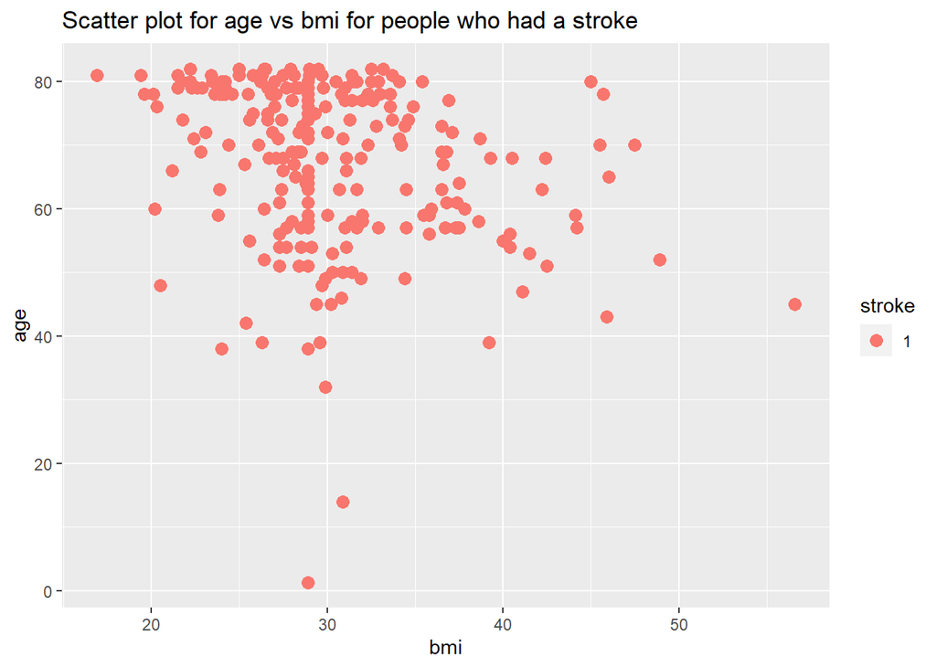

```r
ggplot(stroke_1, aes(x=bmi, y=age, color=stroke))+geom_point(size=3)+ ggtitle("Scatter plot for age vs bmi for people who had a stroke")
```

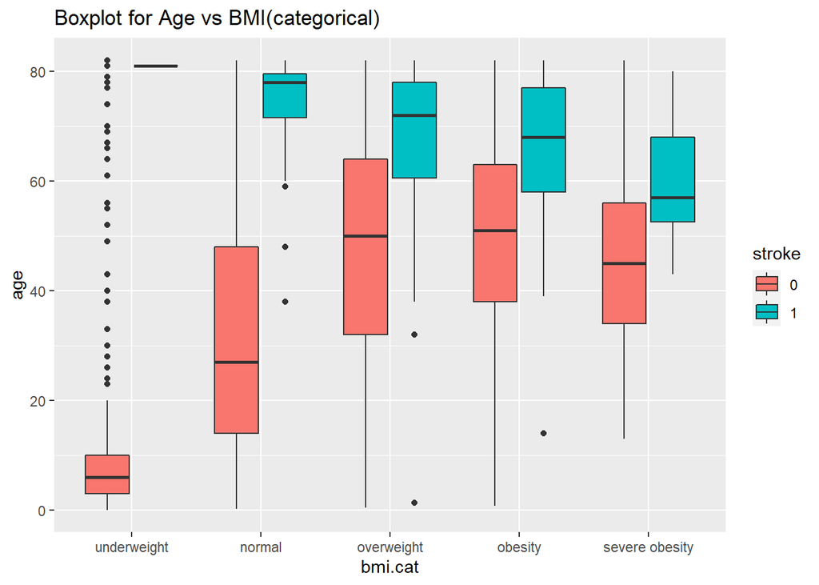

```r
ggplot(dat, aes(x=bmi.cat,y = age, fill=stroke))+geom_boxplot()+ ggtitle("Boxplot for Age vs BMI(categorical)")
```

Since the previous scatter plot provided a rough estimate of where the majority of the strokes occurred. Hence divided into different pre-defined categories.

The categories are encoded as:

- Underweight - BMI < 18.5
- Normal - BMI >= 18.5 and BMI <= 25
- Overweight - BMI >= 25.0 and BMI <= 30
- Obesity - BMI >= 30.0 and BMI < 40
- “Extreme” or Severe Obesity - BMI >= 40

```r
#Chi square test for BMI categorical

ctest1 = chisq.test(dat$bmi.cat, dat$stroke)
ctest1
```

```
##
##  Pearson's Chi-squared test
##
## data:  dat$bmi.cat and dat$stroke
## X-squared = 44.95, df = 4, p-value = 4.072e-09
```

As we can see from the chi-squared test, the p-value is less than 0.05, So we fail to accept the null hypothesis and can conclude that BMI is related to stroke.

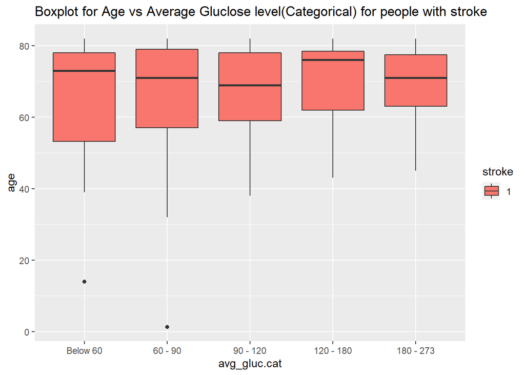

```r
#

stroke_1_dat = subset(dat, stroke==1 )
ggplot(stroke_1_dat, aes(fill=stroke, y = age, x = avg_gluc.cat))+ geom_boxplot()+ ggtitle("Boxplot for Age vs Average Gluclose level(Categorical) for people with stroke")
```

```r
ctest1 = chisq.test(dat$avg_gluc.cat, dat$stroke)
ctest1
```

```
##
##  Pearson's Chi-squared test
##
## data:  dat$avg_gluc.cat and dat$stroke
## X-squared = 107.26, df = 4, p-value < 2.2e-16
```

We can see from this test that the p-value is less than 0.05, so we cannot accept the null hypothesis and can conclude that average glucose level is dependent on stroke.

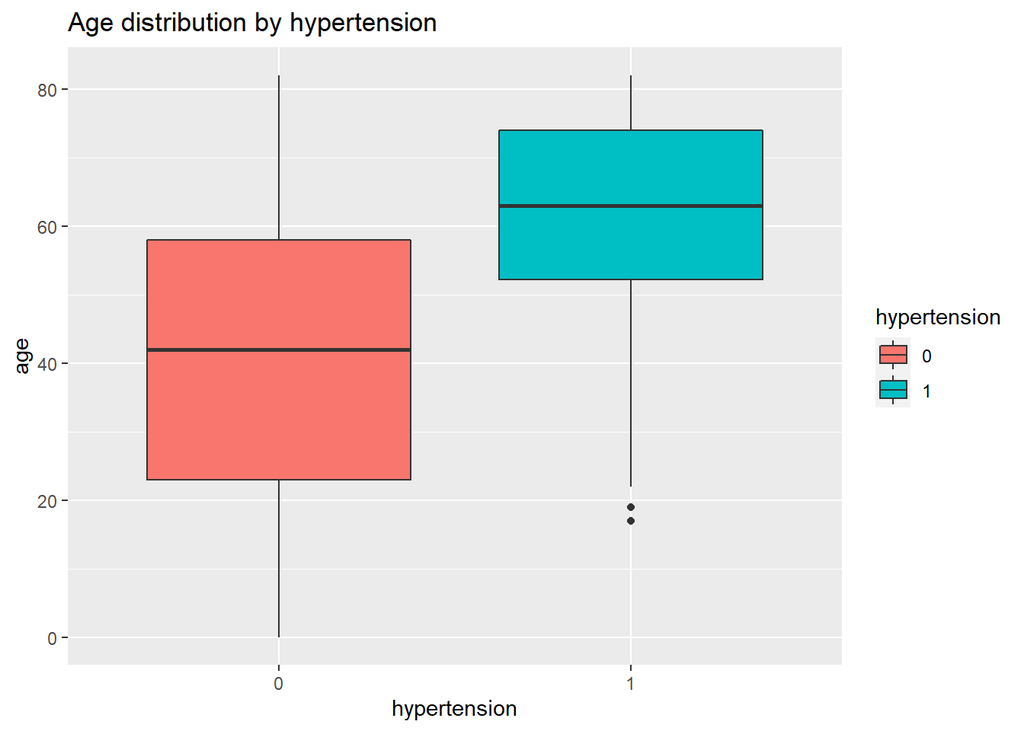

```r
ggplot(data = stroke_df, aes(x=as.character(hypertension), y=age, fill=hypertension)) +
    geom_boxplot() +
    labs(title="Age distribution by hypertension", x="hypertension", y="age")
```

```r
# Chi square test for Hypertension vs Stroke
ctest3 = chisq.test(stroke_df$hypertension, stroke_df$stroke)
ctest3
```

```
##
##  Pearson's Chi-squared test with Yates' continuity correction
##
## data:  stroke_df$hypertension and stroke_df$stroke
## X-squared = 81.573, df = 1, p-value < 2.2e-16
```

H1 Accepted: Hypertension is dependent

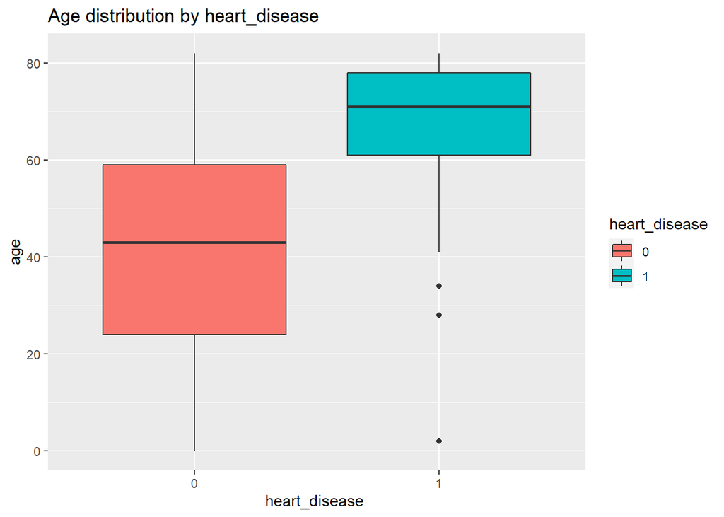

```r
ggplot(data = stroke_df, aes(x=as.character(heart_disease ), y=age, fill=heart_disease)) +
    geom_boxplot() +
    labs(title="Age distribution by heart_disease ", x="heart_disease ", y="age")
```

```r
#Chi square test Heart Disease vs stroke
ctest4 = chisq.test(stroke_df$heart_disease, stroke_df$stroke)
ctest4
```

```
##
##  Pearson's Chi-squared test with Yates' continuity correction
##
## data:  stroke_df$heart_disease and stroke_df$stroke
## X-squared = 90.229, df = 1, p-value < 2.2e-16
```

As we can see from the results, the p values less than 0.05, thus we can fail to accept the null hypothesis and infer that Heart disease and are related to stroke.

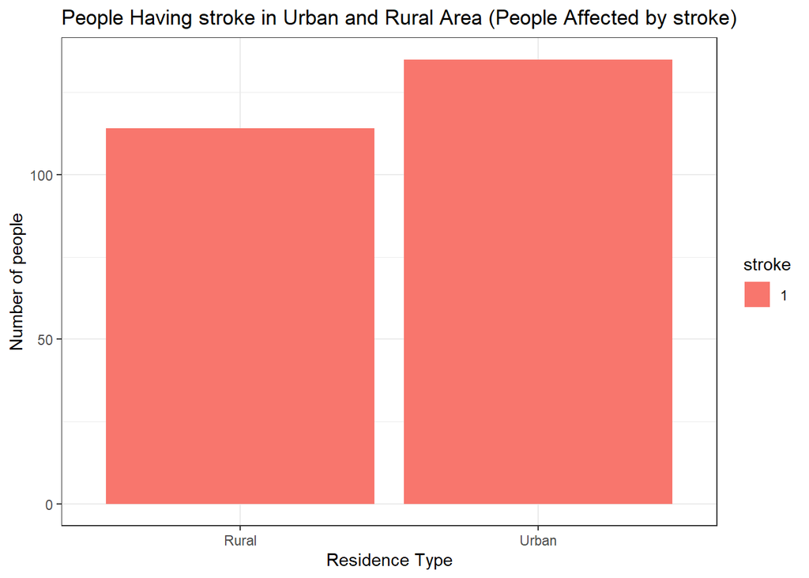

```r
ggplot(stroke_1_dat, aes(x=Residence_type,fill=stroke))+geom_bar(position = "dodge")+ggtitle("People Having stroke in Urban and Rural Area (People Affected by stroke)")+ theme_bw() +theme()+ xlab("Residence Type") + ylab("Number of people")
```

The above graph represents only stroke affected people in Rural and Urban Residence.

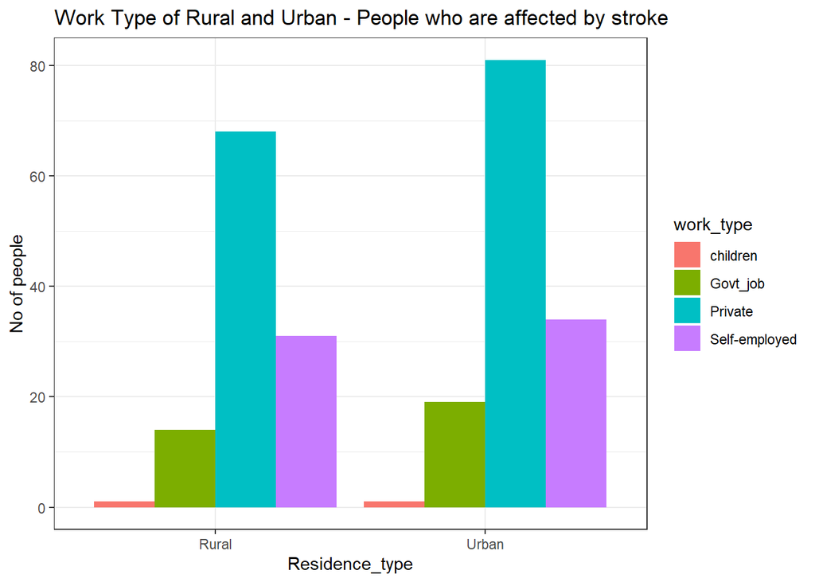

```r
ggplot(stroke_1_dat,aes(x=Residence_type,fill=work_type))+geom_bar(position="dodge")+ggtitle("Work Type of Rural and Urban - People who are affected by stroke ")+theme()+theme_bw()+ylab("No of people")
```

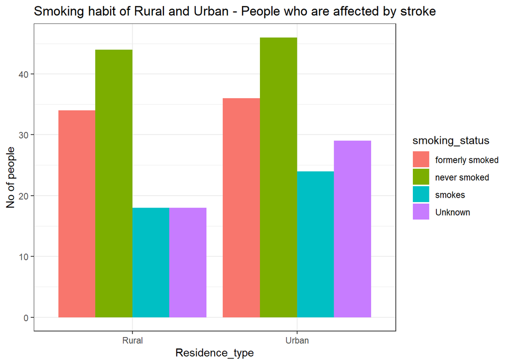

```r
ggplot(stroke_1_dat,aes(x=Residence_type,fill=smoking_status))+geom_bar(position="dodge")+ggtitle("Smoking habit of Rural and Urban - People who are affected by stroke ")+theme()+theme_bw()+ylab("No of people")
```

```r
ch<-table(stroke_df$Residence_type, stroke_df$stroke)
chisq.test(stroke_df$Residence_type, stroke_df$stroke)
```

```
##
##  Pearson's Chi-squared test with Yates' continuity correction
##
## data:  stroke_df$Residence_type and stroke_df$stroke
## X-squared = 1.075, df = 1, p-value = 0.2998
```